# Day 17: Bagging and Random Forests — In-Class Activity (Solutions)

Does this suburb have a high crime rate? Let 500 trees vote.

Instructor

```r
data(Boston)
boston <- Boston %>%
  mutate(HighCrime = factor(if_else(crim > median(crim), "Yes", "No"))) %>%
  select(-crim)
```

## Part 1: A Shape a Straight Line Can’t Draw

### Task 1.1: Look at two predictors

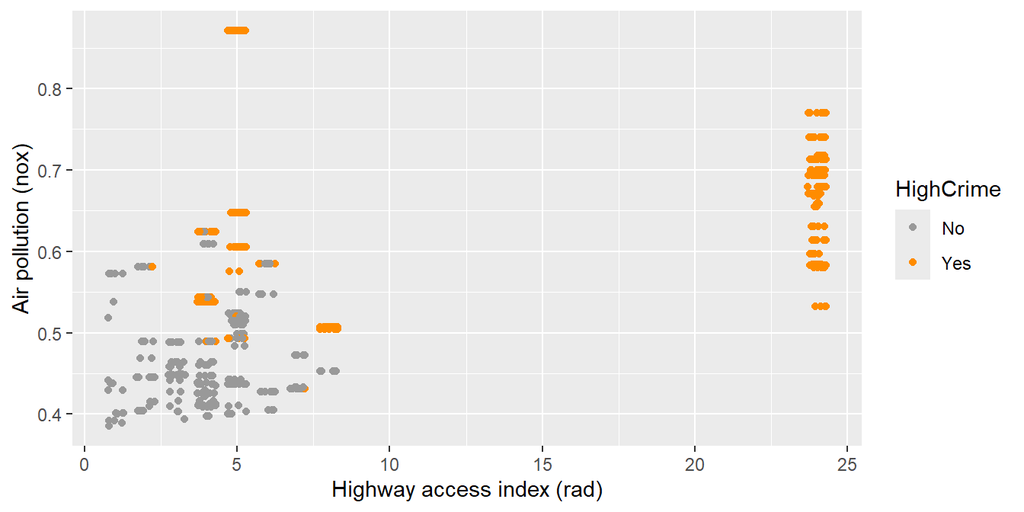

```r
ggplot(boston, aes(rad, nox, color = HighCrime)) +
  geom_jitter(width = 0.3, height = 0) +
  scale_color_manual(values = c(No = "grey60", Yes = "darkorange")) +
  labs(x = "Highway access index (rad)", y = "Air pollution (nox)")
```

```r
by_rad <- boston %>%
  group_by(rad) %>%
  summarise(suburbs = n(), share_high_crime = mean(HighCrime == "Yes"))
by_rad
```

```
## # A tibble: 9 × 3
##     rad suburbs share_high_crime
##   <int>   <int>            <dbl>
## 1     1      20           0
## 2     2      24           0.0417
## 3     3      38           0.0263
## 4     4     110           0.445
## 5     5     115           0.409
## 6     6      26           0.115
## 7     7      17           0.118
## 8     8      24           0.75
## 9    24     132           1
```

The share of high-crime suburbs does **not** rise steadily with `rad`. It’s near zero for `rad` 1–3, jumps to about half for 4–5, drops again for 6–7 (12%, 12%), is high at 8 (75%), and is 100% for all 132 suburbs with `rad` = 24 (central Boston). `rad` is an index, so equal steps don’t mean equal changes. Pollution (`nox`) works more like a threshold: below about 0.53 almost every suburb is low-crime, and above it most are high-crime.

### Task 1.2: One tree vs logistic regression

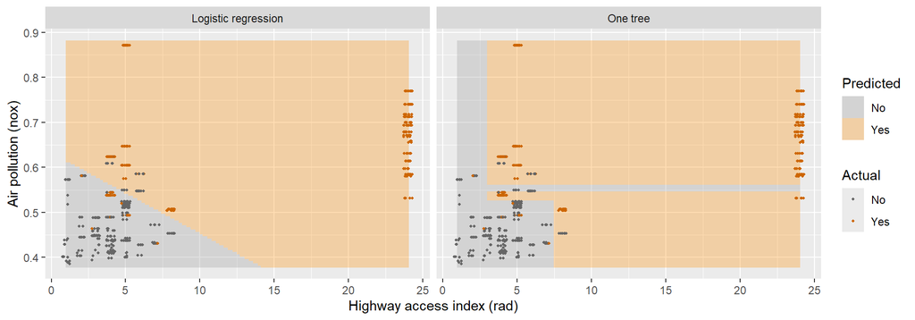

```r
tree2 <- rpart(HighCrime ~ nox + rad, data = boston, method = "class")
logit2 <- glm(HighCrime ~ nox + rad, data = boston, family = binomial)

grid <- expand.grid(rad = seq(1, 24, by = 0.1), nox = seq(0.38, 0.88, by = 0.005))
grid_pred <- bind_rows(
  grid %>% mutate(model = "Logistic regression",
                  pred = if_else(predict(logit2, grid, type = "response") > 0.5, "Yes", "No")),
  grid %>% mutate(model = "One tree",
                  pred = as.character(predict(tree2, grid, type = "class")))
)
ggplot(grid_pred, aes(rad, nox)) +
  geom_raster(aes(fill = pred), alpha = 0.3) +
  geom_jitter(data = boston, aes(color = HighCrime), width = 0.3, height = 0, size = 0.8) +
  facet_wrap(~ model) +
  scale_fill_manual(values = c(No = "grey60", Yes = "darkorange")) +
  scale_color_manual(values = c(No = "grey40", Yes = "darkorange3")) +
  labs(x = "Highway access index (rad)", y = "Air pollution (nox)",
       fill = "Predicted", color = "Actual")
```

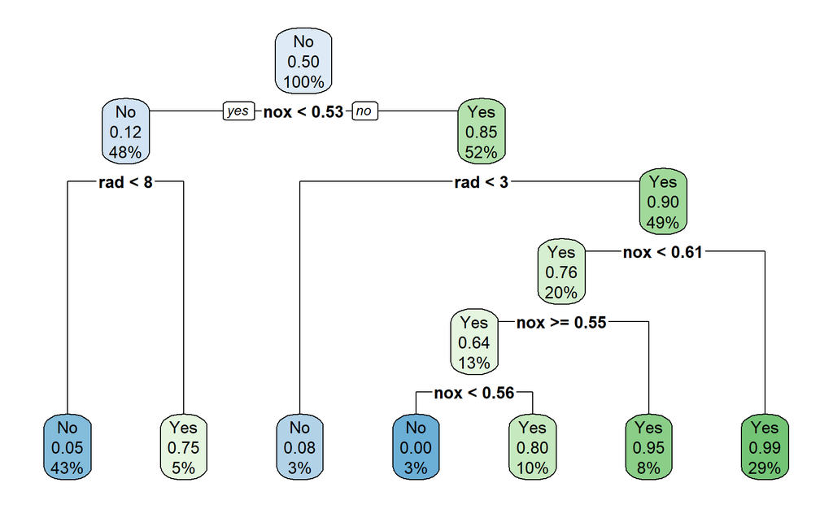

```r
rpart.plot(tree2, type = 2, extra = 106, tweak = 1.2)   # each question is under its box; "yes" goes left
```

**Rule:** if pollution is low (`nox` < 0.53), predict high crime only if the suburb has good highway access (`rad` of 8 or more). If pollution is high, predict high crime unless highway access is poor (`rad` < 3). The tree then adds a few smaller splits on `nox`.

**Where logistic regression goes wrong:** the biggest group is the suburbs with `rad` = 4 and middling pollution (`nox` about 0.53 to 0.6), just above the 0.53 cutoff: 32 of them are high-crime, and the tree gets them right, but they sit on the “No” side of logistic regression’s line.

Logistic regression’s boundary is one slanted line: its log-odds is $\beta_0 + \beta_1 \cdot \text{nox} + \beta_2 \cdot \text{rad}$, so raising `rad` by one always shifts the log-odds by the same amount. But among suburbs with middling pollution, the share of high-crime suburbs goes **up and down** with `rad`: 14% at `rad` = 2, 94% at 4, 18% at 6, and 100% at 24. To call the `rad` = 4 suburbs “Yes”, the line would have to move down far enough to also call the nearby `rad` = 5–6 suburbs “Yes”, and most of those are low-crime. One steady slope can’t go up, down, and up again. The tree’s boxes can: they split on `nox` first and then on `rad`, with different cutoffs on each side.

## Part 2: Many Trees

### Task 2.1: Bagging and a random forest

```r
set.seed(17)
bag <- randomForest(HighCrime ~ ., data = boston, ntree = 500, mtry = 12)
set.seed(17)
forest <- randomForest(HighCrime ~ ., data = boston, ntree = 500, importance = TRUE)

bag$err.rate[500, "OOB"]      # OOB error, bagging
```

```
##        OOB
## 0.04545455
```

```r
forest$err.rate[500, "OOB"]   # OOB error, random forest
```

```
##        OOB
## 0.03754941
```

OOB error: bagging **4.5%**, random forest **3.8%**. The forest is lower, by 4 suburbs out of 506.

### Task 2.2: What do the trees ask first?

```r
first_question <- function(rf) {
  sapply(1:rf$ntree, function(k) as.character(getTree(rf, k, labelVar = TRUE)[1, "split var"]))
}
bag_first <- sort(table(first_question(bag)), decreasing = TRUE)
forest_first <- sort(table(first_question(forest)), decreasing = TRUE)
bag_first
```

```
##
##   nox indus
##   495     5
```

```r
forest_first
```

```
##
##     nox   indus     age     tax     rad     dis ptratio   lstat    medv      zn
##     122      94      69      60      59      47      30       7       6       6
```

```r
round(cor(boston[, c("nox", "indus", "age", "dis", "rad", "tax")]), 2)
```

```
##         nox indus   age   dis   rad   tax
## nox    1.00  0.76  0.73 -0.77  0.61  0.67
## indus  0.76  1.00  0.64 -0.71  0.60  0.72
## age    0.73  0.64  1.00 -0.75  0.46  0.51
## dis   -0.77 -0.71 -0.75  1.00 -0.49 -0.53
## rad    0.61  0.60  0.46 -0.49  1.00  0.91
## tax    0.67  0.72  0.51 -0.53  0.91  1.00
```

**495 of the 500 bagged trees** start with nox. `nox`, `indus`, `age`, `dis`, and `tax` all measure how **old, industrial, and central** a suburb is: polluted suburbs have more industry, older homes, are closer to the city’s employment centers, and pay higher taxes (correlations of about 0.5 to 0.8 in absolute value). They carry much of the same information, and `nox` is the best single one, so bagging starts almost every tree with it.

Trees that all start with `nox` at about the same cutoff look alike, so they make the **same mistakes**, and the vote can’t cancel those out. In the random forest, each split may only choose from 3 random predictors, so `nox` leads only 122 trees; the others start with indus, age, tax, rad, dis, and so on. Those trees approach the same pattern through different, related predictors, so their mistakes differ more, and the vote averages more of them away.

**In plain words:** imagine asking 500 people for advice, but they all read the same newspaper first. They’d tend to be wrong about the same things, so asking 500 of them is not much better than asking a few. Bagging is like that: almost every tree looks at pollution first and ends up reasoning the same way. The random forest makes each tree start from a randomly chosen handful of facts, so different trees lean on industry, home age, taxes, or distance instead. When one tree is fooled by a suburb, many others reasoned differently and aren’t, so the majority vote is right more often.

## Part 3: The Scoreboard

### Task 3.1: Choosing `mtry` with OOB error

```r
mtrys <- c(1, 2, 3, 4, 6, 9, 12)
oob <- matrix(NA, nrow = length(mtrys), ncol = 3,
              dimnames = list(NULL, c("seed_1", "seed_2", "seed_3")))
for (i in 1:length(mtrys)) {
  for (s in 1:3) {
    set.seed(s)
    fit <- randomForest(HighCrime ~ ., data = boston, ntree = 500, mtry = mtrys[i])
    oob[i, s] <- fit$err.rate[500, "OOB"]
  }
}
oob_tab <- tibble(mtry = mtrys, as_tibble(oob))
oob_tab
```

```
## # A tibble: 7 × 4
##    mtry seed_1 seed_2 seed_3
##   <dbl>  <dbl>  <dbl>  <dbl>
## 1     1 0.0435 0.0395 0.0395
## 2     2 0.0356 0.0356 0.0356
## 3     3 0.0356 0.0356 0.0395
## 4     4 0.0375 0.0395 0.0356
## 5     6 0.0435 0.0395 0.0375
## 6     9 0.0435 0.0415 0.0415
## 7    12 0.0455 0.0415 0.0435
```

`mtry` = 2 and 3 do best (averaged over the seeds: 3.6% and 3.7%). Bagging (`mtry` = 12) is worse with **all three** seeds (average 4.3%). The best `mtry` gains about **4 suburbs** out of 506 over bagging: real, but small. `mtry` = 1 is worse again: a split that sees only one random predictor often has to use a weak one. Of the three in the prediction, the worst on average is **`mtry` = 12** (mtry = 1: 4.1%; mtry = 3: 3.7%; mtry = 12: 4.3%).

### Task 3.2: All four methods, on three sets of folds

```r
methods <- c("logistic", "one tree", "bagging", "random forest")
cv_error <- matrix(NA, nrow = 3, ncol = 4, dimnames = list(paste("folds", 1:3), methods))
for (s in 1:3) {
  set.seed(s)
  fold <- sample(rep(1:5, length.out = nrow(boston)))
  errors <- matrix(NA, nrow = 5, ncol = 4, dimnames = list(NULL, methods))
  for (f in 1:5) {
    train <- boston[fold != f, ]
    test  <- boston[fold == f, ]

    logit <- glm(HighCrime ~ ., data = train, family = binomial)
    p <- predict(logit, test, type = "response")
    errors[f, "logistic"] <- mean(if_else(p > 0.5, "Yes", "No") != test$HighCrime)

    tree <- rpart(HighCrime ~ ., data = train, method = "class")
    errors[f, "one tree"] <- mean(predict(tree, test, type = "class") != test$HighCrime)

    set.seed(f)
    bag_f <- randomForest(HighCrime ~ ., data = train, ntree = 500, mtry = 12)
    errors[f, "bagging"] <- mean(predict(bag_f, test) != test$HighCrime)

    set.seed(f)
    rf_f <- randomForest(HighCrime ~ ., data = train, ntree = 500)
    errors[f, "random forest"] <- mean(predict(rf_f, test) != test$HighCrime)
  }
  cv_error[s, ] <- colMeans(errors)
}
cv_error                # one row per set of folds
```

```
##           logistic   one tree    bagging random forest
## folds 1 0.09079790 0.06119200 0.04931081    0.03546884
## folds 2 0.10869734 0.05725102 0.05131043    0.04148709
## folds 3 0.09877694 0.05527082 0.05329062    0.04736944
```

```r
avg <- colMeans(cv_error)
avg                     # averaged over the three
```

```
##      logistic      one tree       bagging random forest
##    0.09942406    0.05790461    0.05130395    0.04144179
```

From worst to best: logistic regression (9.9%), one tree (5.8%), bagging (5.1%), random forest (4.1%). The ranking is the same for all three sets of folds.

- **Logistic → tree (Part 1), 4.2 points.** Crime follows thresholds (`nox` above about 0.53, `rad` of 24) and an interaction (`rad` matters differently at low and high pollution). Trees find these on their own; logistic regression adds up straight-line effects.
- **Tree → bagging, 0.7 points.** A single tree changes a lot with the training data (high variance). The vote of 500 trees on bootstrap samples averages much of that variance away.
- **Bagging → forest (Part 2), 1.0 points.** Bagged trees all start with `nox` and make similar mistakes; forcing some trees to start with `indus`, `age`, `tax`, … makes their mistakes more different, so the vote cancels more of them.

The first step is worth by far the most: choosing a method that fits the **shape** of the data. The two ensemble steps are each worth about a point (3–5 suburbs out of 506), but they show up in every set of folds.

**Is the forest’s edge luck?** The forest beats bagging on all three sets of folds, by 1.4, 1.0, 0.6 points. If the edge were luck, we’d expect bagging to win on some fold assignments. The three rows share the same 506 suburbs, so this doesn’t prove the forest would win on new data, but it rules out one lucky split. The gain is small but consistent, and Part 2 gives a reason for it.

## Bonus

### Bonus 1: Tell logistic regression the shape

```r
logit_shape <- rep(NA, 3)
for (s in 1:3) {
  set.seed(s)
  fold <- sample(rep(1:5, length.out = nrow(boston)))
  errors <- rep(NA, 5)
  for (f in 1:5) {
    train <- boston[fold != f, ]
    test  <- boston[fold == f, ]
    logit <- glm(HighCrime ~ . - rad + factor(rad), data = train, family = binomial)
    p <- predict(logit, test, type = "response")
    errors[f] <- mean(if_else(p > 0.5, "Yes", "No") != test$HighCrime)
  }
  logit_shape[s] <- mean(errors)
}
logit_shape
```

```
## [1] 0.04735003 0.06126966 0.05727043
```

```r
mean(logit_shape)
```

```
## [1] 0.05529671
```

With `rad` as categories, logistic regression goes from 9.9% to **5.5%**: the jumpy effect of `rad` was most of what it was missing. Now it beats the single tree (5.8%) and is close to bagging (5.1%), but it still trails the forest (4.1%). We had to notice the shape first (Task 1.1) and write it into the formula by hand; the trees found it, and the thresholds in `nox`, on their own.

### Bonus 2: Which predictors matter?

```r
imp <- importance(forest, type = 1, scale = FALSE)
imp_tab <- tibble(predictor = rownames(imp), accuracy_lost = imp[, 1]) %>%
  arrange(desc(accuracy_lost))
imp_tab
```

```
## # A tibble: 12 × 2
##    predictor accuracy_lost
##    <chr>             <dbl>
##  1 nox            0.161
##  2 indus          0.101
##  3 rad            0.0883
##  4 tax            0.0733
##  5 ptratio        0.0571
##  6 dis            0.0514
##  7 age            0.0163
##  8 rm             0.0117
##  9 medv           0.0116
## 10 zn             0.00930
## 11 lstat          0.00879
## 12 chas           0.000561
```

The top predictors are **nox, indus, rad, tax**: pollution, industry, highway access, and taxes, the “old, industrial, central” group from Part 2. The table says **how much** each predictor matters, not which way: we know more pollution goes with more crime from Part 1’s plot, not from this table.

### Bonus 3: Back to the colleges

On the colleges, whether a college is private changes **smoothly** with tuition and enrollment: higher tuition and fewer students mean more likely private, with no thresholds or interactions for a straight line in the log-odds to miss. Logistic regression already fits that shape, so one tree (which can only draw boxes) does worse, and averaging trees only brings them up to logistic regression’s level. In Boston, crime follows thresholds and an interaction, which is what trees capture and logistic regression can’t. **Which method wins depends on the shape of the data.**